# Multiple Testing y Reinforcement Learning

## Introducción

En este tutorial se abordarán dos temas: las pruebas múltiples y el aprendizaje por refuerzo. En la primera parte se utilizará la base de datos NCI60, que contiene mediciones de expresión genética de líneas celulares de cáncer. Se aplicarán PCA y K-means para formar grupos y después se compararán dos clusters mediante pruebas t. Se utilizarán las correcciones de Bonferroni, Holm y Benjamini–Hochberg para observar cómo cambia la selección de variables significativas al considerar la cantidad de pruebas realizadas. Además, una simulación de lanzamiento de monedas ayudará a explicar cómo pueden aparecer resultados extremos por azar.

En la segunda parte se trabajará con CartPole, un ambiente donde un carro debe mantener un poste en equilibrio. Primero se evaluará un agente que realiza acciones aleatorias y después se entrenará uno mediante Q-learning. Se analizarán las recompensas, la evolución del entrenamiento y el desempeño final. También se generará un video con un control auxiliar de posición para explorar su efecto sobre el movimiento del carro.

El objetivo es explicar paso a paso qué se realiza, por qué se hace y qué indican los resultados, de manera que el lector pueda reproducir el trabajo y comprender los alcances y las limitaciones de cada procedimiento.

## Parte 1. Multiple Testing

### Paso 1. Importación de las librerías

Para comenzar, se importarán las librerías necesarias para manipular los datos, construir las gráficas y realizar el análisis estadístico.

También se importarán las herramientas para estandarizar las variables, aplicar PCA, realizar K-means y corregir los p-values de las pruebas de hipótesis.

```python
# Manipulación de datos
import pandas as pd
import numpy as np

# Visualización
%pip install ISLP
import matplotlib.pyplot as plt
import seaborn as sns
from IPython.display import display

# Base de datos
from ISLP import load_data

# Preparación y agrupamiento
from sklearn.preprocessing import StandardScaler
from sklearn.decomposition import PCA
from sklearn.cluster import KMeans

# Pruebas de hipótesis y correcciones
from scipy.stats import ttest_ind
from statsmodels.stats.multitest import multipletests

# Configuración de las gráficas
sns.set_theme(style="whitegrid")

colores = [
    "#E76F9A",
    "#8C78C8",
    "#5EB8B2",
    "#E8B65C",
    "#729ECE"
]

SEMILLA = 27
```

### Paso 2. Carga de la base de datos NCI60

Se cargará la base de datos NCI60 desde la librería ISLP. Se separarán las mediciones de expresión genética y las etiquetas de cáncer.

Las etiquetas se conservarán para describir las observaciones, pero no se utilizarán para formar los clusters. De esta manera, el agrupamiento dependerá de las mediciones genéticas.

```python
# Cargar la base de datos
nci60 = load_data("NCI60")

# Mediciones de expresión genética
X_genes = pd.DataFrame(nci60["data"]).copy()

# Etiquetas de cáncer
etiquetas_cancer = pd.Series(
    np.asarray(nci60["labels"]).ravel(),
    index=X_genes.index,
    name="Tipo de cáncer"
)

# Resumen de la base
resumen_datos = pd.DataFrame({
    "Característica": [
        "Líneas celulares",
        "Variables genéticas",
        "Tipos de cáncer",
        "Valores faltantes en expresión genética"
    ],
    "Cantidad": [
        X_genes.shape[0],
        X_genes.shape[1],
        etiquetas_cancer.nunique(),
        int(X_genes.isna().sum().sum())
    ]
})

display(
    resumen_datos.style
    .hide(axis="index")
    .set_caption("Características de la base de datos NCI60")
)

display(X_genes.iloc[:5, :6])
```

Características de la base de datos NCI60

| Característica | Cantidad |
| --- | --- |
| Líneas celulares | 64 |
| Variables genéticas | 6830 |
| Tipos de cáncer | 14 |
| Valores faltantes en expresión genética | 0 |

|  | 0 | 1 | 2 | 3 | 4 | 5 |
| --- | --- | --- | --- | --- | --- | --- |
| 0 | 0.300000 | 1.180000 | 0.550000 | 1.140000 | -0.265000 | -7.000000e-02 |
| 1 | 0.679961 | 1.289961 | 0.169961 | 0.379961 | 0.464961 | 5.799610e-01 |
| 2 | 0.940000 | -0.040000 | -0.170000 | -0.040000 | -0.605000 | 0.000000e+00 |
| 3 | 0.280000 | -0.310000 | 0.680000 | -0.810000 | 0.625000 | -1.387779e-17 |
| 4 | 0.485000 | -0.465000 | 0.395000 | 0.905000 | 0.200000 | -5.000000e-03 |

La base de datos NCI60 contiene 64 líneas celulares y 6,830 variables genéticas, con 14 etiquetas distintas en la categoría de cáncer. No se encontraron valores faltantes en las mediciones de expresión genética, por lo que no será necesario completar datos antes de continuar.

La segunda tabla muestra las primeras cinco líneas celulares y seis variables genéticas. Cada fila representa una línea celular y cada columna una variable. Como existen muchas más variables que observaciones, se utilizará PCA para reducir las dimensiones y conservar gran parte de la variación de los datos.

### Paso 3. Estandarización de las variables

Antes de aplicar PCA, se estandarizarán las variables genéticas para que cada una tenga un promedio cercano a cero y una desviación estándar cercana a uno.

Este paso permite que las variables se analicen en una escala comparable. Se conservarán los datos originales, ya que posteriormente se utilizarán para realizar las pruebas de hipótesis.

```python
# Comprobar que los datos puedan utilizarse
if not np.isfinite(X_genes.to_numpy(dtype=float)).all():
    raise ValueError(
        "Existen valores faltantes o infinitos. "
        "Es necesario revisarlos antes de continuar."
    )

# Estandarizar las variables
escalador = StandardScaler()

X_genes_std = escalador.fit_transform(X_genes)

print("Dimensiones de los datos estandarizados:", X_genes_std.shape)
```

```
Dimensiones de los datos estandarizados: (64, 6830)
```

La estandarización conserva la cantidad de observaciones y variables. Lo que cambia es la escala de las mediciones.

### Paso 4. Aplicación de PCA

Se aplicará PCA para obtener componentes que concentren la variación de las variables genéticas. Siguiendo el criterio utilizado en el tutorial anterior, se conservará la cantidad de componentes necesaria para explicar al menos el 80 % de la variación total.

Los clusters se construirán utilizando todos los componentes seleccionados. Los primeros dos se utilizarán únicamente para visualizar las observaciones en una gráfica.

```python
# Conservar al menos el 80 % de la varianza
pca = PCA(
    n_components=0.80,
    svd_solver="full"
)

componentes = pca.fit_transform(X_genes_std)

# Guardar los componentes
X_nci_pca = pd.DataFrame(
    componentes,
    index=X_genes.index,
    columns=[
        f"PC{i + 1}"
        for i in range(componentes.shape[1])
    ]
)

# Varianza explicada
varianza_acumulada = np.cumsum(
    pca.explained_variance_ratio_
)

resumen_pca = pd.DataFrame({
    "Componente": X_nci_pca.columns,
    "Varianza explicada (%)": (
        pca.explained_variance_ratio_ * 100
    ),
    "Varianza acumulada (%)": (
        varianza_acumulada * 100
    )
})

display(
    resumen_pca.style
    .format({
        "Varianza explicada (%)": "{:.2f}",
        "Varianza acumulada (%)": "{:.2f}"
    })
    .hide(axis="index")
    .set_caption("Varianza explicada por los componentes seleccionados")
)

print(f"Componentes seleccionados: {pca.n_components_}")
print(
    "Varianza total conservada: "
    f"{varianza_acumulada[-1]:.2%}"
)
```

Varianza explicada por los componentes seleccionados

| Componente | Varianza explicada (%) | Varianza acumulada (%) |
| --- | --- | --- |
| PC1 | 11.36 | 11.36 |
| PC2 | 6.76 | 18.12 |
| PC3 | 5.75 | 23.87 |
| PC4 | 4.25 | 28.11 |
| PC5 | 3.73 | 31.85 |
| PC6 | 3.62 | 35.47 |
| PC7 | 3.07 | 38.53 |
| PC8 | 2.69 | 41.22 |
| PC9 | 2.53 | 43.75 |
| PC10 | 2.38 | 46.13 |
| PC11 | 2.36 | 48.48 |
| PC12 | 2.16 | 50.65 |
| PC13 | 2.05 | 52.70 |
| PC14 | 1.98 | 54.67 |
| PC15 | 1.92 | 56.59 |
| PC16 | 1.77 | 58.36 |
| PC17 | 1.66 | 60.02 |
| PC18 | 1.61 | 61.63 |
| PC19 | 1.59 | 63.23 |
| PC20 | 1.56 | 64.79 |
| PC21 | 1.51 | 66.30 |
| PC22 | 1.48 | 67.78 |
| PC23 | 1.44 | 69.21 |
| PC24 | 1.36 | 70.57 |
| PC25 | 1.32 | 71.90 |
| PC26 | 1.28 | 73.17 |
| PC27 | 1.26 | 74.43 |
| PC28 | 1.21 | 75.64 |
| PC29 | 1.18 | 76.82 |
| PC30 | 1.12 | 77.94 |
| PC31 | 1.08 | 79.03 |
| PC32 | 1.04 | 80.07 |

```
Componentes seleccionados: 32
Varianza total conservada: 80.07%
```

Se seleccionaron 32 componentes principales, que conservan el 80.07 % de la variación total de los datos. Por lo tanto, se cumplió el criterio de conservar al menos el 80 %.

Esto permite representar las 6,830 variables genéticas mediante 32 componentes para realizar el agrupamiento. La reducción facilita el análisis, aunque deja fuera el 19.93 % de la variación original.

### Paso 5. Agrupamiento con K-means

Se utilizará K-means para formar cinco clusters.

El algoritmo utilizará los componentes seleccionados por PCA. Se establecerá una semilla para que el resultado sea reproducible y se probarán varias inicializaciones para reducir la dependencia de una sola selección inicial de centroides.

```python
# Ajustar K-means
modelo_kmeans = KMeans(
    n_clusters=5,
    n_init=50,
    random_state=SEMILLA
)

# Numerar los clusters del 1 al 5
clusters = pd.Series(
    modelo_kmeans.fit_predict(X_nci_pca) + 1,
    index=X_genes.index,
    name="Cluster"
)

# Cantidad de observaciones por cluster
tabla_clusters = (
    clusters.value_counts()
    .sort_index()
    .rename_axis("Cluster")
    .reset_index(name="Número de observaciones")
)

display(
    tabla_clusters.style
    .hide(axis="index")
    .set_caption("Distribución de líneas celulares por cluster")
)
```

Distribución de líneas celulares por cluster

| Cluster | Número de observaciones |
| --- | --- |
| 1 | 9 |
| 2 | 25 |
| 3 | 6 |
| 4 | 20 |
| 5 | 4 |

Las 64 líneas celulares se distribuyeron en cinco clusters de distintos tamaños. El cluster 2 contiene la mayor cantidad de observaciones, con 25, seguido del cluster 4, con 20. Los clusters 1, 3 y 5 contienen 9, 6 y 4 observaciones, respectivamente.

K-means no exige que los grupos tengan el mismo tamaño, por lo que esta distribución es posible. Los números únicamente identifican los clusters, no indican importancia ni calidad. Posteriormente, se comparará la expresión genética entre los clusters 1 y 2, que contienen 9 y 25 observaciones.

### Paso 6. Visualización de PC1 contra PC2

Se graficarán las observaciones utilizando los primeros dos componentes principales. Cada punto representará una línea celular y su color indicará el cluster asignado por K-means.

Esta gráfica permitirá observar parte de la separación entre los grupos. Sin embargo, el agrupamiento se realizó utilizando todos los componentes seleccionados, por lo que una superposición en esta vista no implica que las observaciones sean iguales en las demás dimensiones.

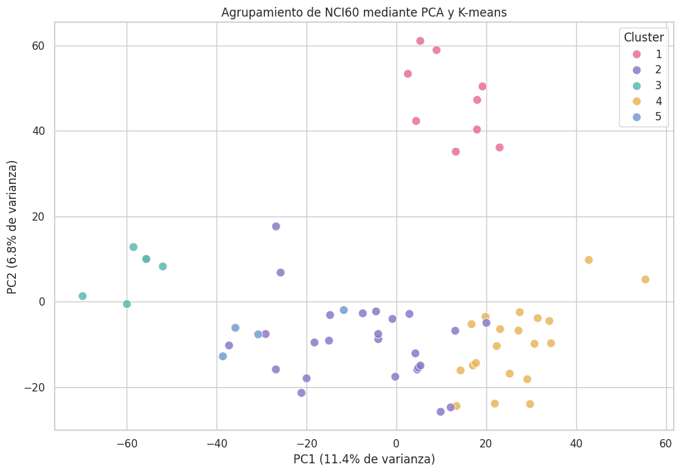

```python
# Preparar los datos para graficar
datos_grafica = X_nci_pca[["PC1", "PC2"]].copy()
datos_grafica["Cluster"] = clusters.astype(str)

plt.figure(figsize=(10, 7))

sns.scatterplot(
    data=datos_grafica,
    x="PC1",
    y="PC2",
    hue="Cluster",
    hue_order=["1", "2", "3", "4", "5"],
    palette=colores,
    s=80,
    alpha=0.85,
    edgecolor="white"
)

plt.title("Agrupamiento de NCI60 mediante PCA y K-means")

plt.xlabel(
    f"PC1 ({pca.explained_variance_ratio_[0]:.1%} de varianza)"
)
plt.ylabel(
    f"PC2 ({pca.explained_variance_ratio_[1]:.1%} de varianza)"
)

plt.legend(title="Cluster")
plt.tight_layout()
plt.show()
```

La gráfica muestra que el cluster 1, en rosa, se distingue por sus valores altos en PC2, mientras que el cluster 3, en verde, se concentra en valores negativos de PC1. El cluster 4, en amarillo, aparece principalmente hacia la derecha. Los clusters 2 y 5 presentan mayor cercanía y cierta superposición en esta vista.

Los primeros dos componentes explican aproximadamente el 18.2 % de la variación total, por lo que la gráfica muestra solo una parte de la información utilizada para formar los grupos. K-means utilizó los 32 componentes seleccionados, por ello, dos puntos cercanos en esta imagen pueden presentar diferencias en los demás componentes.

A continuación, se comparará la expresión de cada variable genética entre los clusters 1 y 2 mediante pruebas t.

### Paso 7. Separación de los clusters

Se seleccionarán los clusters 1 y 2. Estos grupos fueron obtenidos previamente con K-means utilizando los 32 componentes principales. Sus números son identificadores y no implican que sean los grupos más diferentes. En esta ejecución contienen 9 y 25 líneas celulares, respectivamente.

Para la comparación se utilizarán las variables genéticas originales. Los componentes de PCA se utilizaron para formar los grupos, pero ahora interesa identificar qué genes presentan diferencias en su expresión promedio.

```python
# Recuperar las variables originales de cada grupo
genes_cluster1 = X_genes.loc[clusters == 1]
genes_cluster2 = X_genes.loc[clusters == 2]

print(f"Observaciones del cluster 1: {len(genes_cluster1)}")
print(f"Observaciones del cluster 2: {len(genes_cluster2)}")
print(f"Variables genéticas por comparar: {X_genes.shape[1]}")
```

```
Observaciones del cluster 1: 9
Observaciones del cluster 2: 25
Variables genéticas por comparar: 6830
```

### Paso 8. Definición de las hipótesis

Para cada variable genética se realizará una prueba t bilateral con las siguientes hipótesis:

- Hipótesis nula (H₀): la expresión promedio es igual en ambos grupos.
- Hipótesis alternativa (H₁): la expresión promedio es diferente entre los grupos. Se utilizará la prueba t de Welch, que no exige que ambos grupos tengan la misma varianza. Inicialmente se establecerá un nivel de significancia de 0.05, sin aplicar todavía correcciones por pruebas múltiples.

Un p-value menor que 0.05 llevará a rechazar la hipótesis nula en esta primera comparación.

### Paso 9. Prueba t para cada variable genética

Se realizará una prueba para cada una de las 6,830 variables. Se guardarán los promedios de ambos clusters, su diferencia, el estadístico t y el p-value.

La diferencia se calculará como promedio del cluster 1 menos promedio del cluster 2. Un resultado positivo indicará mayor expresión promedio en el cluster 1, uno negativo indicará mayor expresión en el cluster 2.

```python
# Pruebas t de Welch para todas las variables
estadisticos_t, p_values = ttest_ind(
    genes_cluster1.to_numpy(),
    genes_cluster2.to_numpy(),
    axis=0,
    equal_var=False,
    alternative="two-sided"
)

# Guardar los resultados
resultados_t = pd.DataFrame({
    "Variable genética": X_genes.columns,
    "Promedio cluster 1": genes_cluster1.mean().to_numpy(),
    "Promedio cluster 2": genes_cluster2.mean().to_numpy(),
    "Estadístico t": estadisticos_t,
    "p-value": p_values
})

resultados_t["Diferencia de promedios"] = (
    resultados_t["Promedio cluster 1"]
    - resultados_t["Promedio cluster 2"]
)

# Identificar pruebas con un p-value válido
pruebas_validas = np.isfinite(resultados_t["p-value"])

# Mantener como no evaluables las pruebas sin p-value válido
resultados_t["Significativa sin corrección"] = pd.Series(
    pd.NA,
    index=resultados_t.index,
    dtype="boolean"
)

resultados_t.loc[
    pruebas_validas, "Significativa sin corrección"
] = resultados_t.loc[pruebas_validas, "p-value"] < 0.05

print(f"Pruebas realizadas: {len(resultados_t)}")
print(f"Pruebas con p-value válido: {pruebas_validas.sum()}")
print(f"Pruebas no evaluables: {(~pruebas_validas).sum()}")
```

```
Pruebas realizadas: 6830
Pruebas con p-value válido: 6830
Pruebas no evaluables: 0
```

Se realizaron 6,830 pruebas t de Welch, una por cada variable genética, para comparar la expresión promedio entre los clusters 1 y 2. Todas generaron un p-value válido, por lo que no fue necesario excluir ninguna prueba.

Estos resultados confirman que se pudo completar el cálculo para todas las variables, pero todavía no indican cuántas presentan diferencias significativas. Eso se revisará al comparar los p-values con el umbral de 0.05.

### Paso 10. Variables con los menores p-values

Se mostrarán las diez variables con los menores p-values. Para facilitar la lectura, los promedios y sus diferencias se presentarán en una tabla, y los estadísticos de las pruebas en otra.

Los identificadores corresponden a las columnas originales de la base de datos, no son nombres biológicos de genes.

```python
# Seleccionar las diez variables con menor p-value
top10_t = (
    resultados_t.loc[pruebas_validas]
    .sort_values("p-value")
    .head(10)
)

# Comparación de promedios
display(
    top10_t[[
        "Variable genética",
        "Promedio cluster 1",
        "Promedio cluster 2",
        "Diferencia de promedios"
    ]]
    .style
    .format({
        "Promedio cluster 1": "{:.3f}",
        "Promedio cluster 2": "{:.3f}",
        "Diferencia de promedios": "{:.3f}"
    })
    .hide(axis="index")
    .set_caption(
        "Expresión promedio de las diez variables con menor p-value"
    )
)

# Resultados de las pruebas
display(
    top10_t[[
        "Variable genética",
        "Estadístico t",
        "p-value"
    ]]
    .style
    .format({
        "Estadístico t": "{:.3f}",
        "p-value": "{:.3e}"
    })
    .hide(axis="index")
    .set_caption("Resultados de las pruebas t de Welch")
)
```

Expresión promedio de las diez variables con menor p-value

| Variable genética | Promedio cluster 1 | Promedio cluster 2 | Diferencia de promedios |
| --- | --- | --- | --- |
| 4326 | 4.341 | -0.101 | 4.442 |
| 4346 | 2.180 | -0.521 | 2.701 |
| 4300 | 1.738 | -0.181 | 1.919 |
| 4360 | 1.537 | -0.507 | 2.043 |
| 4315 | 1.610 | 0.014 | 1.596 |
| 4275 | 1.060 | -0.284 | 1.344 |
| 4337 | 1.952 | -0.029 | 1.981 |
| 2023 | -0.934 | 0.391 | -1.326 |
| 4339 | 2.330 | -0.199 | 2.529 |
| 4276 | 1.201 | -0.277 | 1.478 |

Resultados de las pruebas t de Welch

| Variable genética | Estadístico t | p-value |
| --- | --- | --- |
| 4326 | 13.707 | 6.955e-15 |
| 4346 | 12.916 | 3.279e-14 |
| 4300 | 14.296 | 1.046e-13 |
| 4360 | 12.836 | 1.560e-13 |
| 4315 | 14.996 | 2.118e-12 |
| 4275 | 11.338 | 3.950e-12 |
| 4337 | 11.565 | 5.569e-12 |
| 2023 | -10.778 | 8.289e-12 |
| 4339 | 10.975 | 1.691e-11 |
| 4276 | 10.039 | 2.112e-11 |

Las diez variables mostradas presentan p-values menores que 0.05, por lo que se consideran significativas en la comparación sin corrección. La variable 4326 tiene el menor p-value, de aproximadamente 6.955 × 10⁻¹⁵, y una expresión promedio de 4.341 en el cluster 1 frente a −0.101 en el cluster 2.

Nueve de estas variables presentan mayor expresión promedio en el cluster 1. La excepción es la variable 2023, cuyo promedio es −0.934 en el cluster 1 y 0.391 en el cluster 2, con una diferencia de −1.326.

Estos resultados describen diferencias entre los grupos, pero un p-value pequeño no demuestra importancia biológica. Además, como los clusters se formaron con los mismos datos genéticos, la comparación es exploratoria. Posteriormente se aplicarán las correcciones por pruebas múltiples.

### Paso 11. Cantidad de variables significativas sin corrección

Se contará cuántas pruebas presentan un p-value menor que 0.05 y cuántas no cumplen este criterio. Este resultado servirá como referencia para compararlo posteriormente con las correcciones por pruebas múltiples.

```python
# Conteos de las pruebas
n_significativas = int(
    resultados_t["Significativa sin corrección"].sum()
)

n_no_significativas = int(
    (
        resultados_t.loc[pruebas_validas, "p-value"] >= 0.05
    ).sum()
)

n_no_evaluables = int((~pruebas_validas).sum())

resumen_t = pd.DataFrame({
    "Resultado": [
        "Significativas: p < 0.05",
        "No significativas: p ≥ 0.05",
        "No evaluables"
    ],
    "Número de variables": [
        n_significativas,
        n_no_significativas,
        n_no_evaluables
    ]
})

resumen_t["Porcentaje del total"] = (
    resumen_t["Número de variables"]
    / len(resultados_t)
    * 100
)

display(
    resumen_t.style
    .format({"Porcentaje del total": "{:.2f} %"})
    .hide(axis="index")
    .set_caption(
        "Significancia de las variables sin corrección por pruebas múltiples"
    )
)
```

Significancia de las variables sin corrección por pruebas múltiples

| Resultado | Número de variables | Porcentaje del total |
| --- | --- | --- |
| Significativas: p < 0.05 | 2577 | 37.73 % |
| No significativas: p ≥ 0.05 | 4253 | 62.27 % |
| No evaluables | 0 | 0.00 % |

Sin aplicar correcciones por pruebas múltiples, 2,577 variables genéticas (37.73%) presentaron un p-value menor que 0.05 y se clasificaron como significativas. Las otras 4,253 variables (62.27%) no alcanzaron este criterio. Todas las pruebas pudieron evaluarse.

Esta clasificación es preliminar: al realizar 6,830 pruebas, algunas pueden resultar significativas por azar. Las correcciones permitirán revisar cuántas mantienen la significancia al considerar el conjunto de comparaciones, aunque el análisis seguirá siendo exploratorio porque los clusters se formaron con los mismos datos.

### Paso 12. Distribución de los p-values

Se construirá un histograma para observar cómo se distribuyen los p-values. La línea vertical marcará el umbral de 0.05 utilizado en las pruebas individuales.

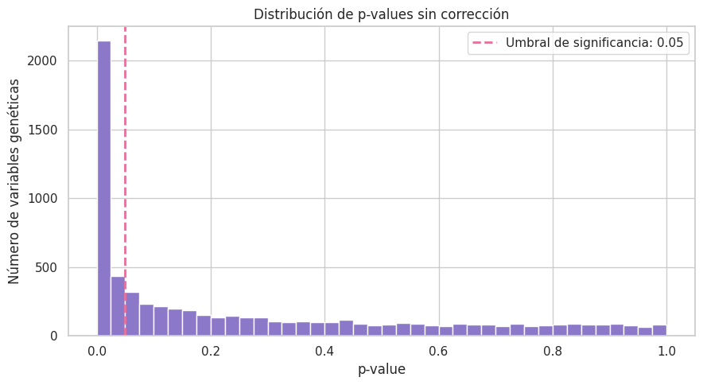

```python
plt.figure(figsize=(9, 5))

plt.hist(
    resultados_t.loc[pruebas_validas, "p-value"],
    bins=np.linspace(0, 1, 41),
    color="#8C78C8",
    edgecolor="white"
)

plt.axvline(
    0.05,
    color="#E76F9A",
    linestyle="--",
    linewidth=2,
    label="Umbral de significancia: 0.05"
)

plt.title("Distribución de p-values sin corrección")
plt.xlabel("p-value")
plt.ylabel("Número de variables genéticas")
plt.legend()
plt.tight_layout()
plt.show()
```

El histograma muestra una gran concentración de p-values cercanos a cero. En total, 2,577 variables (37.73%) se encuentran por debajo del umbral de 0.05, señalado con la línea rosa, y se consideran significativas sin corrección.

Sin embargo, la gráfica no permite distinguir cuáles de estos resultados podrían ser falsos positivos. Al realizar 6,830 pruebas, es necesario aplicar correcciones por comparaciones múltiples antes de interpretar la cantidad de variables significativas.

Además, los grupos se formaron con las mismas mediciones genéticas que ahora se comparan, lo que favorece encontrar diferencias. Por ello, el análisis seguirá siendo exploratorio incluso después de corregir los p-values.

### Paso 13. Simulación del torneo

Se simulará un torneo con 1,000 participantes. Cada persona lanzará una moneda justa 10 veces y se registrará cuántas caras obtiene.

En esta simulación todas las monedas tendrán una probabilidad de 0.5 de caer en cara. Por lo tanto, cualquier resultado extremo aparecerá por azar, sin que exista una moneda alterada.

```python
# Generador aleatorio reproducible
rng_monedas = np.random.default_rng(SEMILLA)

n_participantes = 1000
n_lanzamientos = 10

# Número de caras obtenido por cada participante
caras = rng_monedas.binomial(
    n=n_lanzamientos,
    p=0.5,
    size=n_participantes
)

torneo = pd.DataFrame({
    "Participante": np.arange(1, n_participantes + 1),
    "Caras": caras,
    "Cruces": n_lanzamientos - caras
})

display(
    torneo.head(10).style
    .hide(axis="index")
    .set_caption("Resultados de los primeros diez participantes")
)
```

Resultados de los primeros diez participantes

| Participante | Caras | Cruces |
| --- | --- | --- |
| 1 | 6 | 4 |
| 2 | 4 | 6 |
| 3 | 3 | 7 |
| 4 | 4 | 6 |
| 5 | 7 | 3 |
| 6 | 6 | 4 |
| 7 | 1 | 9 |
| 8 | 4 | 6 |
| 9 | 4 | 6 |
| 10 | 7 | 3 |

La tabla muestra los resultados de los primeros diez participantes. Aunque todos utilizaron monedas justas, obtuvieron distintas cantidades de caras y cruces. Por ejemplo, el participante 1 obtuvo seis caras y cuatro cruces, mientras que el participante 7 obtuvo una cara y nueve cruces.

Estas diferencias son producto del azar, una probabilidad de 0.5 no significa que cada persona deba obtener exactamente cinco caras y cinco cruces. Para analizar el torneo completo, se revisarán los resultados de los 1,000 participantes.

### Paso 14. Tabla de frecuencias

Se contará cuántas personas obtuvieron cada resultado, desde cero hasta diez caras. También se calculará la cantidad esperada de participantes para cada resultado bajo una moneda justa.

La distribución binomial permite calcular estas probabilidades porque se realizan diez lanzamientos independientes con la misma probabilidad de cara.

```python
from scipy.stats import binom

# Resultados posibles
resultados_posibles = np.arange(n_lanzamientos + 1)

# Frecuencias observadas
frecuencias = (
    torneo["Caras"]
    .value_counts()
    .reindex(resultados_posibles, fill_value=0)
    .sort_index()
)

# Probabilidades teóricas para una moneda justa
probabilidades = binom.pmf(
    resultados_posibles,
    n=n_lanzamientos,
    p=0.5
)

tabla_monedas = pd.DataFrame({
    "Número de caras": resultados_posibles,
    "Participantes observados": frecuencias.to_numpy(),
    "Participantes esperados": (
        n_participantes * probabilidades
    )
})

display(
    tabla_monedas.style
    .format({"Participantes esperados": "{:.2f}"})
    .hide(axis="index")
    .set_caption("Distribución de resultados del torneo")
)
```

Distribución de resultados del torneo

| Número de caras | Participantes observados | Participantes esperados |
| --- | --- | --- |
| 0 | 0 | 0.98 |
| 1 | 10 | 9.77 |
| 2 | 56 | 43.95 |
| 3 | 111 | 117.19 |
| 4 | 182 | 205.08 |
| 5 | 260 | 246.09 |
| 6 | 211 | 205.08 |
| 7 | 115 | 117.19 |
| 8 | 46 | 43.95 |
| 9 | 9 | 9.77 |
| 10 | 0 | 0.98 |

El resultado más frecuente fue cinco caras, obtenido por 260 participantes, frente a los 246.09 esperados. La mayoría de los resultados se concentró entre cuatro y seis caras, mientras que ninguno de los participantes obtuvo cero o diez caras.

Las diferencias entre las cantidades observadas y esperadas se deben a la variación aleatoria de la simulación. Por ejemplo, esperar 0.98 participantes con diez caras no garantiza que aparezca uno en cada torneo, simplemente representa un promedio entre muchas repeticiones.

### Paso 15. Histograma de resultados

Se graficará la cantidad de caras obtenida por los participantes y se añadirá la frecuencia esperada para cada resultado.

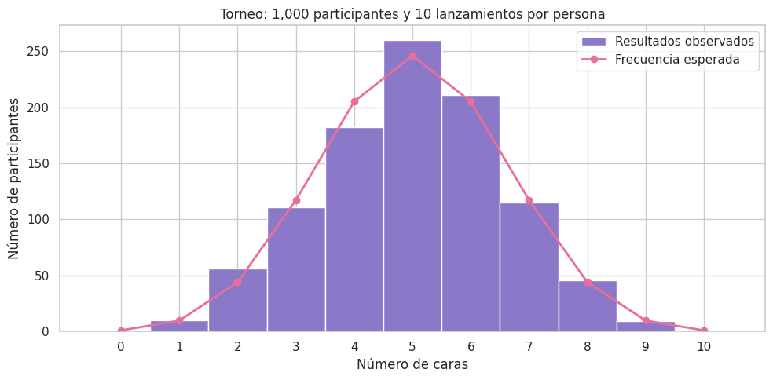

```python
plt.figure(figsize=(10, 5))

plt.hist(
    torneo["Caras"],
    bins=np.arange(-0.5, n_lanzamientos + 1.5, 1),
    color="#8C78C8",
    edgecolor="white",
    label="Resultados observados"
)

plt.plot(
    resultados_posibles,
    tabla_monedas["Participantes esperados"],
    color="#E76F9A",
    marker="o",
    linewidth=2,
    label="Frecuencia esperada"
)

plt.title("Torneo: 1,000 participantes y 10 lanzamientos por persona")
plt.xlabel("Número de caras")
plt.ylabel("Número de participantes")
plt.xticks(resultados_posibles)
plt.legend()
plt.tight_layout()
plt.show()
```

El histograma muestra que los resultados se concentran alrededor de cinco caras, que fue el resultado más frecuente con 260 participantes. Las barras siguen aproximadamente el patrón de la distribución esperada, representada por la línea rosa, aunque existen diferencias debidas al azar.

Los resultados extremos fueron menos frecuentes, diez participantes obtuvieron una cara y nueve obtuvieron nueve caras. Ninguno obtuvo cero o diez caras en este torneo, aunque ambos resultados son posibles con una moneda justa.

### Paso 16. Probabilidad de resultados extremos

Para una persona, la probabilidad de obtener diez caras es aproximadamente 0.098 %. La probabilidad de obtener diez cruces es la misma.

Sin embargo, al participar 1,000 personas, existen muchas oportunidades para que ocurra alguno de estos resultados. Se calculará la probabilidad de que al menos una persona obtenga diez caras y la de que al menos una obtenga diez caras o diez cruces.

```python
# Probabilidades individuales
p_diez_caras = binom.pmf(10, n=10, p=0.5)
p_diez_cruces = binom.pmf(0, n=10, p=0.5)

p_cualquier_extremo = p_diez_caras + p_diez_cruces

# Probabilidad de al menos un caso entre 1,000 participantes
p_al_menos_diez_caras = (
    1 - (1 - p_diez_caras) ** n_participantes
)

p_al_menos_un_extremo = (
    1 - (1 - p_cualquier_extremo) ** n_participantes
)

tabla_probabilidades = pd.DataFrame({
    "Evento": [
        "Una persona obtiene 10 caras",
        "Una persona obtiene 10 caras o 10 cruces",
        "Al menos una de 1,000 obtiene 10 caras",
        "Al menos una de 1,000 obtiene 10 caras o 10 cruces"
    ],
    "Probabilidad (%)": [
        p_diez_caras * 100,
        p_cualquier_extremo * 100,
        p_al_menos_diez_caras * 100,
        p_al_menos_un_extremo * 100
    ]
})

display(
    tabla_probabilidades.style
    .format({"Probabilidad (%)": "{:.3f}"})
    .hide(axis="index")
    .set_caption("Probabilidades individuales y del torneo completo")
)

print(
    "Participantes que obtuvieron 10 caras:",
    int((torneo["Caras"] == 10).sum())
)

print(
    "Participantes que obtuvieron 10 cruces:",
    int((torneo["Caras"] == 0).sum())
)
```

Probabilidades individuales y del torneo completo

| Evento | Probabilidad (%) |
| --- | --- |
| Una persona obtiene 10 caras | 0.098 |
| Una persona obtiene 10 caras o 10 cruces | 0.195 |
| Al menos una de 1,000 obtiene 10 caras | 62.358 |
| Al menos una de 1,000 obtiene 10 caras o 10 cruces | 85.844 |

```
Participantes que obtuvieron 10 caras: 0
Participantes que obtuvieron 10 cruces: 0
```

La probabilidad de que una persona obtenga diez caras es de aproximadamente 0.098 %, pero la de que al menos una de las 1,000 personas lo consiga aumenta a 62.358 %. Al considerar ambos extremos, diez caras o diez cruces, alcanza el 85.844 %.

En esta simulación nadie obtuvo esos resultados. Esto no contradice las probabilidades: todavía existe aproximadamente un 14.156 % de posibilidad de que no aparezca ninguno de los dos extremos.

El ejemplo muestra que un resultado poco probable para una persona puede ser frecuente al considerar muchos participantes. De manera similar, realizar muchas pruebas de hipótesis aumenta las oportunidades de encontrar resultados significativos por azar, lo que motiva las correcciones por pruebas múltiples.

### Paso 17. Preparación de los p-values

Sin corrección se identificaron 2,577 variables con un p-value menor que 0.05. Ahora se aplicarán métodos que consideran la cantidad total de pruebas realizadas.

Se utilizarán dos criterios:

- FWER: probabilidad de cometer al menos un falso positivo en el conjunto de pruebas. Se aplicarán Bonferroni y Holm con un nivel de 0.05.
- FDR: proporción esperada de falsos positivos entre las hipótesis rechazadas. Se aplicará Benjamini–Hochberg con un nivel de 0.01.

Estas interpretaciones requieren que se cumplan los supuestos correspondientes. En este ejercicio, los grupos se construyeron con los mismos datos comparados, por lo que los ajustes se utilizarán con fines exploratorios.

```python
# Seleccionar los p-values válidos
mascara_validos = np.isfinite(resultados_t["p-value"])

p_validos = resultados_t.loc[
    mascara_validos, "p-value"
].to_numpy()

m = len(p_validos)

alpha_fwer = 0.05
nivel_fdr = 0.01

print(f"Número de pruebas por ajustar: {m}")
print(f"Nivel para controlar FWER: {alpha_fwer}")
print(f"Nivel para controlar FDR: {nivel_fdr}")
```

```
Número de pruebas por ajustar: 6830
Nivel para controlar FWER: 0.05
Nivel para controlar FDR: 0.01
```

### Paso 18. Corrección de Bonferroni

Bonferroni divide el nivel de significancia entre la cantidad de pruebas, en este caso sería un valor aproximado de 0.00000732.

Por lo tanto, una variable necesita un p-value mucho menor que 0.05 para considerarse significativa.

Otra forma equivalente consiste en multiplicar cada p-value por la cantidad de pruebas, limitarlo a uno y comparar ese valor ajustado con 0.05.

```python
# Aplicar Bonferroni
rechazo_bonf, p_bonf, _, _ = multipletests(
    p_validos,
    alpha=alpha_fwer,
    method="bonferroni"
)

# Guardar los p-values ajustados
resultados_t["p Bonferroni"] = np.nan

resultados_t.loc[
    mascara_validos, "p Bonferroni"
] = p_bonf

# Guardar las decisiones
resultados_t["Significativa Bonferroni"] = pd.Series(
    pd.NA, index=resultados_t.index, dtype="boolean"
)

resultados_t.loc[
    mascara_validos, "Significativa Bonferroni"
] = rechazo_bonf

print(f"Umbral para el p-value original: {alpha_fwer / m:.3e}")
print(f"Variables significativas: {rechazo_bonf.sum()}")
```

```
Umbral para el p-value original: 7.321e-06
Variables significativas: 188
```

Con la corrección de Bonferroni, el umbral para los p-values originales se redujo a 7.321 × 10⁻⁶. Bajo este criterio, 188 variables permanecieron significativas, frente a las 2,577 identificadas sin corrección.

Esta reducción refleja un criterio más estricto al considerar las 6,830 pruebas realizadas. Las variables que dejaron de ser significativas no necesariamente tienen promedios iguales entre grupos, sus resultados simplemente no alcanzan el nuevo umbral.

### Paso 19. Corrección de Holm

Holm también busca controlar el FWER, pero utiliza un procedimiento secuencial. Primero ordena los p-values de menor a mayor y los compara con umbrales progresivos.

Para los mismos datos y nivel de significancia, Holm puede identificar tantas o más variables significativas que Bonferroni, manteniendo el mismo objetivo de control del error.

```python
# Aplicar Holm
rechazo_holm, p_holm, _, _ = multipletests(
    p_validos,
    alpha=alpha_fwer,
    method="holm"
)

# Guardar los p-values ajustados
resultados_t["p Holm"] = np.nan

resultados_t.loc[
    mascara_validos, "p Holm"
] = p_holm

# Guardar las decisiones
resultados_t["Significativa Holm"] = pd.Series(
    pd.NA, index=resultados_t.index, dtype="boolean"
)

resultados_t.loc[
    mascara_validos, "Significativa Holm"
] = rechazo_holm

print(f"Variables significativas con Holm: {rechazo_holm.sum()}")
```

```
Variables significativas con Holm: 191
```

Con la corrección de Holm, 191 variables permanecieron significativas, tres más que con Bonferroni, que identificó 188. Ambos métodos utilizan un nivel de FWER de 0.05, pero Holm aplica umbrales secuenciales que pueden permitir detectar más diferencias.

En este caso, la diferencia entre ambos métodos fue pequeña. Los dos redujeron considerablemente la selección respecto a las 2,577 variables significativas sin corrección.

### Paso 20. Corrección de Benjamini–Hochberg

Benjamini–Hochberg busca controlar el FDR. En lugar de controlar la probabilidad de cometer cualquier falso positivo, se enfoca en la proporción esperada de falsos positivos entre los resultados declarados significativos.

Se utilizará un nivel de 0.01. Bajo los supuestos del método, esto busca limitar esa proporción esperada al 1 %. No significa que exactamente el 1 % de las variables seleccionadas en esta ejecución sean falsas.

```python
# Aplicar Benjamini–Hochberg
rechazo_bh, p_bh, _, _ = multipletests(
    p_validos,
    alpha=nivel_fdr,
    method="fdr_bh"
)

# Guardar los p-values ajustados
resultados_t["p BH"] = np.nan

resultados_t.loc[
    mascara_validos, "p BH"
] = p_bh

# Guardar las decisiones
resultados_t["Significativa BH"] = pd.Series(
    pd.NA, index=resultados_t.index, dtype="boolean"
)

resultados_t.loc[
    mascara_validos, "Significativa BH"
] = rechazo_bh

print(
    "Variables significativas con Benjamini–Hochberg:",
    rechazo_bh.sum()
)
```

```
Variables significativas con Benjamini–Hochberg: 868
```

Con Benjamini–Hochberg a un nivel de FDR de 0.01, se identificaron 868 variables significativas, frente a las 188 de Bonferroni y las 191 de Holm.

La mayor cantidad se relaciona con el criterio utilizado: Benjamini–Hochberg busca controlar la proporción esperada de falsos positivos entre los resultados seleccionados. Bajo sus supuestos, el objetivo es limitarla al 1 %, pero esto no garantiza que exactamente el 1 % de estas 868 variables sean falsos positivos. La comparación sigue siendo exploratoria porque los clusters se construyeron con los mismos datos.

### Paso 21. Comparación de resultados

Se comparará la cantidad de variables significativas antes y después de los ajustes.

Debe considerarse que Bonferroni y Holm utilizan un nivel de FWER de 0.05, mientras que Benjamini–Hochberg utiliza un nivel de FDR de 0.01. Por ello, la comparación refleja tanto diferencias entre métodos como entre los criterios establecidos.

```python
comparacion_ajustes = pd.DataFrame({
    "Método": [
        "Sin corrección",
        "Bonferroni",
        "Holm",
        "Benjamini–Hochberg"
    ],
    "Criterio": [
        "Individual: 0.05",
        "FWER: 0.05",
        "FWER: 0.05",
        "FDR: 0.01"
    ],
    "Variables significativas": [
        int((p_validos < 0.05).sum()),
        int(rechazo_bonf.sum()),
        int(rechazo_holm.sum()),
        int(rechazo_bh.sum())
    ]
})

comparacion_ajustes["Porcentaje de pruebas válidas"] = (
    comparacion_ajustes["Variables significativas"]
    / m * 100
)

display(
    comparacion_ajustes.style
    .format({"Porcentaje de pruebas válidas": "{:.2f} %"})
    .hide(axis="index")
    .set_caption(
        "Variables significativas según el método de ajuste"
    )
)
```

Variables significativas según el método de ajuste

| Método | Criterio | Variables significativas | Porcentaje de pruebas válidas |
| --- | --- | --- | --- |
| Sin corrección | Individual: 0.05 | 2577 | 37.73 % |
| Bonferroni | FWER: 0.05 | 188 | 2.75 % |
| Holm | FWER: 0.05 | 191 | 2.80 % |
| Benjamini–Hochberg | FDR: 0.01 | 868 | 12.71 % |

Sin corrección se identificaron 2,577 variables significativas (37.73%). Al aplicar Bonferroni y Holm, la cantidad se redujo a 188 (2.75%) y 191 (2.80%), respectivamente. La diferencia entre ambos fue de solo tres variables.

Benjamini–Hochberg seleccionó 868 variables (12.71%). Esta mayor cantidad responde a un criterio distinto: controla el FDR al 1 %, mientras que Bonferroni y Holm buscan controlar el FWER al 5%. Por ello, seleccionar más variables no implica que un método sea mejor.

Los resultados muestran que considerar las pruebas múltiples cambia considerablemente la selección inicial. Sin embargo, las variables descartadas no quedan demostradas como falsos positivos, simplemente no cumplen el criterio ajustado.

### Paso 22. Visualización de la comparación

Se construirá una gráfica para observar cómo cambia la cantidad de variables significativas con cada método.

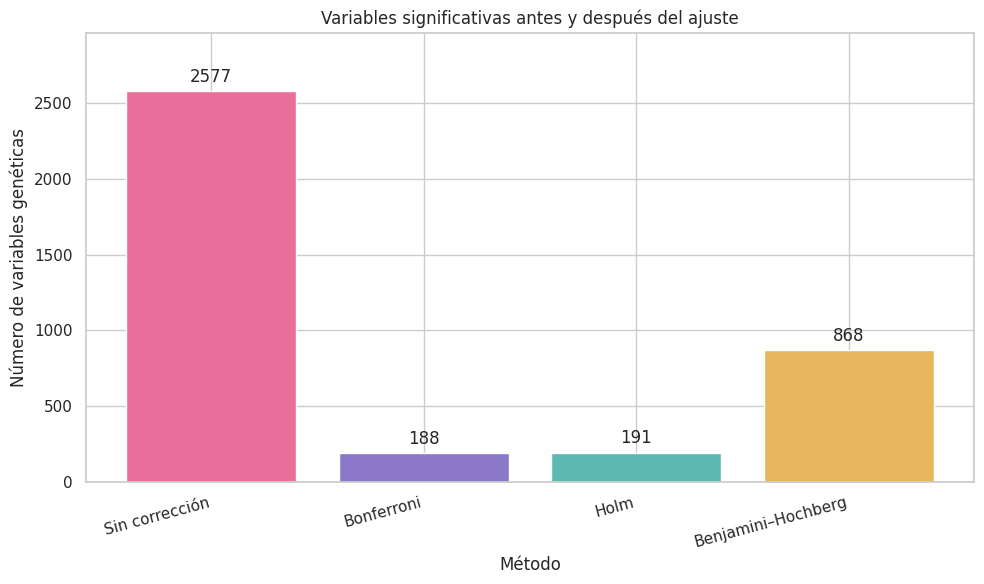

```python
fig, ax = plt.subplots(figsize=(10, 6))

barras = ax.bar(
    comparacion_ajustes["Método"],
    comparacion_ajustes["Variables significativas"],
    color=["#E76F9A", "#8C78C8", "#5EB8B2", "#E8B65C"]
)

ax.bar_label(barras, padding=4, fmt="%d")
ax.margins(y=0.15)

ax.set_title("Variables significativas antes y después del ajuste")
ax.set_xlabel("Método")
ax.set_ylabel("Número de variables genéticas")

plt.xticks(rotation=15, ha="right")
plt.tight_layout()
plt.show()
```

La gráfica muestra una reducción considerable de las variables significativas después del ajuste. Sin corrección se seleccionaron 2,577 variables, mientras que Bonferroni y Holm conservaron 188 y 191, respectivamente, con resultados muy similares.

Benjamini–Hochberg conservó 868 variables, una cantidad mayor porque utiliza un criterio distinto, controlar el FDR al 1%, mientras que los otros métodos buscan controlar el FWER al 5%. Seleccionar más variables no implica un mejor resultado, la elección depende del tipo de error que se desea controlar y del objetivo del análisis.

### Paso 23. Comparación de los p-values ajustados

Finalmente, se mostrarán los p-values originales y ajustados de las diez variables con menor p-value original.

```python
tabla_p_ajustados = (
    resultados_t.loc[mascara_validos]
    .sort_values("p-value")
    .head(10)
    [[
        "Variable genética",
        "p-value",
        "p Bonferroni",
        "p Holm",
        "p BH"
    ]]
)

display(
    tabla_p_ajustados.style
    .format({
        "p-value": "{:.3e}",
        "p Bonferroni": "{:.3e}",
        "p Holm": "{:.3e}",
        "p BH": "{:.3e}"
    })
    .hide(axis="index")
    .set_caption(
        "P-values originales y ajustados de las diez primeras variables"
    )
)
```

P-values originales y ajustados de las diez primeras variables

| Variable genética | p-value | p Bonferroni | p Holm | p BH |
| --- | --- | --- | --- | --- |
| 4326 | 6.955e-15 | 4.750e-11 | 4.750e-11 | 4.750e-11 |
| 4346 | 3.279e-14 | 2.240e-10 | 2.239e-10 | 1.120e-10 |
| 4300 | 1.046e-13 | 7.146e-10 | 7.144e-10 | 2.382e-10 |
| 4360 | 1.560e-13 | 1.066e-09 | 1.065e-09 | 2.664e-10 |
| 4315 | 2.118e-12 | 1.446e-08 | 1.446e-08 | 2.893e-09 |
| 4275 | 3.950e-12 | 2.698e-08 | 2.696e-08 | 4.497e-09 |
| 4337 | 5.569e-12 | 3.804e-08 | 3.800e-08 | 5.434e-09 |
| 2023 | 8.289e-12 | 5.661e-08 | 5.655e-08 | 7.076e-09 |
| 4339 | 1.691e-11 | 1.155e-07 | 1.154e-07 | 1.283e-08 |
| 4276 | 2.112e-11 | 1.443e-07 | 1.441e-07 | 1.417e-08 |

Las diez variables con los menores p-values originales mantuvieron la significancia con los tres métodos. Sus valores ajustados permanecen por debajo de 0.05 para Bonferroni y Holm, y de 0.01 para Benjamini–Hochberg.

Por ejemplo, el p-value de la variable 4326 aumentó de 6.955 × 10⁻¹⁵ a 4.750 × 10⁻¹¹ con los tres ajustes, pero sigue siendo muy inferior a los umbrales establecidos. Bonferroni y Holm produjeron valores muy similares, mientras que Benjamini–Hochberg generó valores menores en las otras nueve variables.

Los ajustes modifican la evaluación de significancia, pero no cambian los promedios ni sus diferencias. Estos resultados siguen siendo exploratorios y no demuestran, por sí solos, importancia biológica.

## Parte 2. Reinforcement Learning

### Paso 24. Instalación de las herramientas

Se instalará Gymnasium para utilizar CartPole, un ambiente donde un carro debe moverse para mantener un poste equilibrado. También se instalarán las herramientas necesarias para mostrar el ambiente y generar videos.

```python
%pip install "gymnasium[classic-control]" imageio imageio-ffmpeg pyvirtualdisplay
!apt-get update -qq
!apt-get install -y -qq xvfb
```

[output not shown]

### Paso 25. Importación y preparación del display

Se importarán las herramientas del ambiente y de video. En un entorno sin pantalla se iniciará un display virtual.

```python
import os
import sys
import shutil
import base64

import gymnasium as gym
import imageio.v2 as imageio

from pathlib import Path
from IPython.display import HTML, display
from pyvirtualdisplay import Display

# Iniciar un display virtual solo si es necesario
if sys.platform.startswith("linux") and not os.environ.get("DISPLAY"):
    if shutil.which("Xvfb") is None:
        raise RuntimeError(
            "Falta Xvfb. Ejecuta la celda de instalación "
            "del sistema antes de continuar."
        )

    display_virtual = Display(
        visible=False,
        size=(1024, 768)
    )

    display_virtual.start()

print("Preparación completada.")
```

```
Preparación completada.
```

### Paso 26. Creación del ambiente

En CartPole el agente puede aplicar una fuerza hacia la izquierda o hacia la derecha. El objetivo es mantener el poste equilibrado durante la mayor cantidad posible de pasos.

El estado contiene cuatro valores:

- Posición del carro.
- Velocidad del carro.
- Ángulo del poste.
- Velocidad angular del poste.

Se utilizará rgb_array para obtener imágenes que después podrán convertirse en video.

```python
# Crear el ambiente
env = gym.make(
    "CartPole-v1",
    render_mode="rgb_array"
)

# Inicializarlo
observacion, informacion = env.reset(seed=SEMILLA)
env.action_space.seed(SEMILLA)

print("Observación inicial:", observacion)
print("Shape de la observación:", observacion.shape)
print("Espacio de acciones:", env.action_space)
print("Espacio de observaciones:", env.observation_space)
```

```
Observación inicial: [ 0.01977362 -0.01861857 -0.03788029 -0.01764085]
Shape de la observación: (4,)
Espacio de acciones: Discrete(2)
Espacio de observaciones: Box([-4.8               -inf -0.41887903        -inf], [4.8               inf 0.41887903        inf], (4,), float32)
```

La observación tendrá cuatro elementos, uno por cada característica del estado. El espacio de acciones será Discrete(2), porque existen dos acciones posibles: 0 para aplicar fuerza a la izquierda y 1 para aplicarla a la derecha.

### Paso 27. Visualización del estado inicial

Se mostrará una imagen del ambiente antes de realizar movimientos.

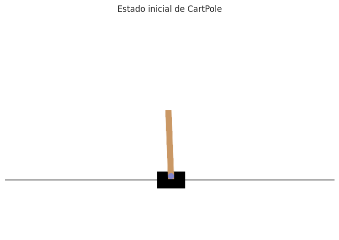

```python
plt.figure(figsize=(8, 5))
plt.imshow(env.render())
plt.title("Estado inicial de CartPole")
plt.axis("off")
plt.tight_layout()
plt.show()

# Variable para controlar el final del episodio
episodio_terminado = False
```

El carro aparece sobre una superficie horizontal con un poste articulado. Aunque el estado inicial suele estar cerca del equilibrio, presenta pequeñas variaciones que el agente deberá compensar con sus acciones.

### Paso 28. Acción hacia la izquierda

Se realizará la acción 0 para aplicar fuerza al carro hacia la izquierda. La función step devolverá el nuevo estado, la recompensa y dos indicadores relacionados con el final del episodio.

- terminated: indica que se alcanzó una condición de fallo.
- truncated: indica que se alcanzó un límite externo, como el máximo de pasos.

Si el episodio anterior terminó, se reiniciará antes de realizar otra acción.

```
Nuevo estado: [-0.06460426 -1.3831688   0.07864894  2.0059898 ]
Recompensa: 1.0
Terminó por fallo: False
Terminó por límite de pasos: False
```

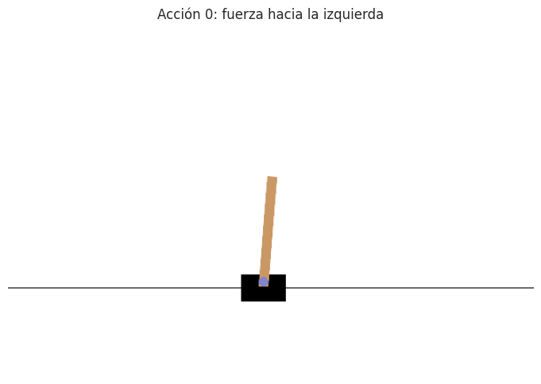

```python
# Reiniciar si el episodio anterior terminó
if episodio_terminado:
    observacion, informacion = env.reset()

# Aplicar fuerza hacia la izquierda
observacion, recompensa, terminated, truncated, informacion = (
    env.step(0)
)

episodio_terminado = terminated or truncated

print("Nuevo estado:", observacion)
print("Recompensa:", recompensa)
print("Terminó por fallo:", terminated)
print("Terminó por límite de pasos:", truncated)

plt.figure(figsize=(8, 5))
plt.imshow(env.render())
plt.title("Acción 0: fuerza hacia la izquierda")
plt.axis("off")
plt.tight_layout()
plt.show()
```

*Nota: Cada vez que se ejecuta la celda, el carro se mueve.

### Paso 29. Acción hacia la derecha

Ahora se realizará la acción 1 para aplicar fuerza hacia la derecha. Puedes alternar la ejecución de estas dos celdas para observar cómo cambia el ambiente.

Una acción aplica una fuerza, el movimiento resultante también depende de la velocidad que ya tenía el carro. Por eso, una sola acción puede producir un cambio visual pequeño y no necesariamente invierte inmediatamente el movimiento.

```
Nuevo estado: [ 0.04819564  0.42054725 -0.05635697 -0.64574   ]
Recompensa: 1.0
Terminó por fallo: False
Terminó por límite de pasos: False
```

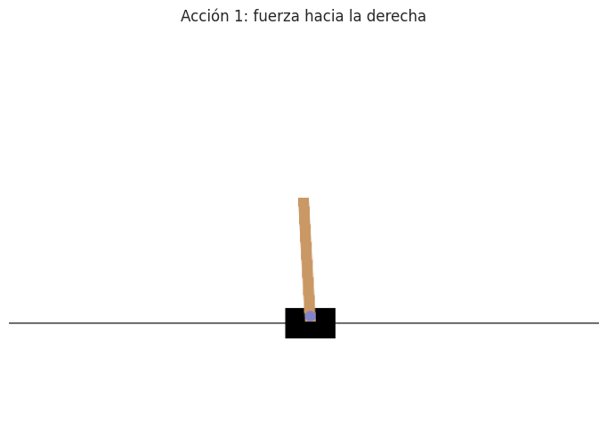

```python
# Reiniciar si el episodio anterior terminó
if episodio_terminado:
    observacion, informacion = env.reset()

# Aplicar fuerza hacia la derecha
observacion, recompensa, terminated, truncated, informacion = (
    env.step(1)
)

episodio_terminado = terminated or truncated

print("Nuevo estado:", observacion)
print("Recompensa:", recompensa)
print("Terminó por fallo:", terminated)
print("Terminó por límite de pasos:", truncated)

plt.figure(figsize=(8, 5))
plt.imshow(env.render())
plt.title("Acción 1: fuerza hacia la derecha")
plt.axis("off")
plt.tight_layout()
plt.show()
```

*Nota: Cada vez que se ejecuta la celda, el carro se mueve.

En la configuración estándar, CartPole entrega una recompensa de +1 por cada transición, incluida la que termina por fallo. Así, la recompensa total representa la duración del intento en pasos. El episodio finaliza cuando el poste se inclina demasiado, el carro sale del rango permitido o se alcanza el límite de 500 pasos.

Estas acciones manuales permiten conocer el ambiente. Todavía no existe aprendizaje, más adelante el agente utilizará sus experiencias para decidir qué acción tomar en cada estado.

### Paso 30. Simulación de 200 pasos

El agente elegirá aleatoriamente entre aplicar fuerza hacia la izquierda o hacia la derecha. No utilizará el estado del ambiente para decidir y tampoco aprenderá de los resultados.

Esta primera demostración continuará durante 200 pasos, aunque el poste haya caído. Se guardará una imagen de cada paso para generar un video.

Los movimientos posteriores al fallo son solo una demostración visual y no forman parte de una evaluación válida del desempeño. También se registrará la recompensa hasta el primer fallo.

```python
# Ambiente exclusivo para la demostración
env_demo = gym.make(
    "CartPole-v1",
    render_mode="rgb_array"
)

observacion, informacion = env_demo.reset(seed=SEMILLA)

rng_acciones = np.random.default_rng(SEMILLA)

frames_aleatorio = [env_demo.render()]

recompensa_demo = 0
recompensa_hasta_fallo = 0
primer_fallo = None

for paso in range(200):

    # Elegir una acción aleatoria
    accion = int(rng_acciones.integers(0, 2))

    # Continuar la física incluso después del fallo
    observacion, recompensa, terminated, truncated, informacion = (
        env_demo.unwrapped.step(accion)
    )

    recompensa_demo += recompensa

    # Contar el desempeño solo hasta el primer fallo
    if primer_fallo is None:
        recompensa_hasta_fallo += recompensa

        if terminated or truncated:
            primer_fallo = paso + 1

    # Guardar imagen del paso
    frames_aleatorio.append(env_demo.render())

env_demo.close()

print("Pasos de la demostración: 200")
print("Primer fallo en el paso:", primer_fallo)
print("Recompensa hasta el primer fallo:", recompensa_hasta_fallo)
print("Suma de recompensas de la demostración:", recompensa_demo)
```

```
Pasos de la demostración: 200
Primer fallo en el paso: 23
Recompensa hasta el primer fallo: 23.0
Suma de recompensas de la demostración: 23.0
```

El agente aleatorio falló en el paso 23, acumulando una recompensa de 23 puntos. Aunque la demostración continuó hasta completar 200 pasos, la suma de recompensas permaneció en 23, los movimientos posteriores al fallo no representan tiempo adicional de equilibrio.

### Paso 31. Generación del video

Las imágenes guardadas se convertirán en un video. Se utilizará la frecuencia de renderizado indicada por el ambiente para representar los movimientos a su velocidad habitual.

```python
# Carpeta para guardar los videos
carpeta_videos = Path("videos_cartpole")
carpeta_videos.mkdir(exist_ok=True)

ruta_video_aleatorio = (
    carpeta_videos / "agente_aleatorio_200_pasos.mp4"
)

# CartPole utiliza habitualmente 50 frames por segundo
fps = env_demo.metadata.get("render_fps", 50)

imageio.mimsave(
    str(ruta_video_aleatorio),
    frames_aleatorio,
    fps=fps,
    macro_block_size=1
)

# Función para mostrar videos dentro del notebook
def mostrar_video(ruta):
    video_base64 = base64.b64encode(
        Path(ruta).read_bytes()
    ).decode("ascii")

    return HTML(
        f"""
        <video width="700" controls>
            <source
                src="data:video/mp4;base64,{video_base64}"
                type="video/mp4">
        </video>
        """
    )

display(mostrar_video(ruta_video_aleatorio))
```

[video not shown]

El video permitirá observar el movimiento generado por acciones aleatorias. El agente no realiza correcciones deliberadas para mantener el equilibrio. Después del primer fallo, las imágenes muestran la continuación de la simulación y no un episodio exitoso.

### Paso 32. Evaluación de 1,000 episodios

Ahora se realizarán 1,000 episodios independientes, sin generar imágenes para acelerar el proceso.

A diferencia de la demostración anterior, cada episodio terminará cuando terminated o truncated sea verdadero. Se registrará la recompensa total de cada intento.

```python
# Ambiente sin renderizado para evaluar más rápido
env_evaluacion = gym.make("CartPole-v1")

rng_evaluacion = np.random.default_rng(SEMILLA)

recompensas_aleatorias = []

for episodio in range(1000):

    observacion, informacion = env_evaluacion.reset(
        seed=SEMILLA + episodio
    )

    done = False
    recompensa_total = 0

    while not done:

        accion = int(rng_evaluacion.integers(0, 2))

        observacion, recompensa, terminated, truncated, informacion = (
            env_evaluacion.step(accion)
        )

        recompensa_total += recompensa
        done = terminated or truncated

    recompensas_aleatorias.append(recompensa_total)

env_evaluacion.close()

recompensas_aleatorias = np.asarray(
    recompensas_aleatorias
)

print("Episodios evaluados:", len(recompensas_aleatorias))
```

```
Episodios evaluados: 1000
```

### Paso 33. Resumen de las recompensar

Se calcularán estadísticas para describir la duración de los episodios del agente aleatorio.

La recompensa promedio indicará cuántos pasos duró un intento en promedio. La desviación estándar mostrará cuánto variaron los resultados entre episodios.

```python
resumen_aleatorio = pd.DataFrame({
    "Estadística": [
        "Episodios evaluados",
        "Recompensa promedio",
        "Mediana",
        "Desviación estándar",
        "Recompensa mínima",
        "Recompensa máxima",
        "Episodios que alcanzaron 500 pasos"
    ],
    "Valor": [
        len(recompensas_aleatorias),
        recompensas_aleatorias.mean(),
        np.median(recompensas_aleatorias),
        recompensas_aleatorias.std(ddof=1),
        recompensas_aleatorias.min(),
        recompensas_aleatorias.max(),
        int((recompensas_aleatorias == 500).sum())
    ]
})

display(
    resumen_aleatorio.style
    .format({"Valor": "{:.2f}"})
    .hide(axis="index")
    .set_caption(
        "Desempeño del agente aleatorio en 1,000 episodios"
    )
)
```

Desempeño del agente aleatorio en 1,000 episodios

| Estadística | Valor |
| --- | --- |
| Episodios evaluados | 1000.00 |
| Recompensa promedio | 21.32 |
| Mediana | 18.00 |
| Desviación estándar | 11.69 |
| Recompensa mínima | 8.00 |
| Recompensa máxima | 141.00 |
| Episodios que alcanzaron 500 pasos | 0.00 |

En los 1,000 episodios evaluados, el agente aleatorio obtuvo una recompensa promedio de 21.32 puntos y una mediana de 18, por lo que la mitad de los intentos duró 18 pasos o menos. La desviación estándar fue de 11.69 puntos, lo que muestra variación entre los intentos.

Las recompensas estuvieron entre 8 y 141 puntos, y ningún episodio alcanzó los 500 pasos. El máximo de 141 corresponde a un intento favorable por azar, no a aprendizaje, ya que el agente no modifica su estrategia. Estos resultados servirán como referencia para compararlo con Q-learning.

### Paso 34. Histograma de recompensas

Se graficará la distribución de las recompensas para identificar qué duración fue más frecuente y qué tan comunes fueron los intentos largos.

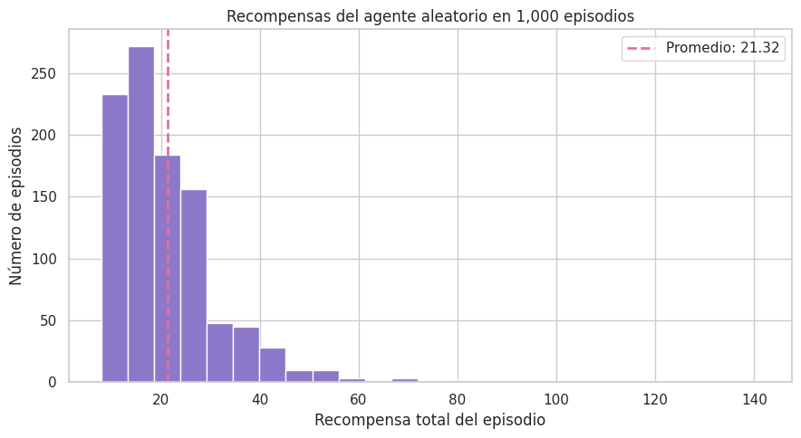

```python
plt.figure(figsize=(9, 5))

plt.hist(
    recompensas_aleatorias,
    bins=25,
    color="#8C78C8",
    edgecolor="white"
)

plt.axvline(
    recompensas_aleatorias.mean(),
    color="#E76F9A",
    linestyle="--",
    linewidth=2,
    label=(
        f"Promedio: "
        f"{recompensas_aleatorias.mean():.2f}"
    )
)

plt.title("Recompensas del agente aleatorio en 1,000 episodios")
plt.xlabel("Recompensa total del episodio")
plt.ylabel("Número de episodios")
plt.legend()
plt.tight_layout()
plt.show()
```

El histograma muestra que la mayoría de los episodios obtuvo recompensas entre 10 y 30 puntos, con un promedio de 21.32, señalado por la línea rosa. La distribución presenta una cola hacia la derecha: hubo pocos intentos largos y uno alcanzó los 141 puntos.

Estos resultados indican que el agente aleatorio suele fallar después de pocos pasos. Los intentos más largos no demuestran aprendizaje, porque el agente continúa eligiendo acciones al azar sin modificar su estrategia. Esta distribución servirá como referencia para compararla con la del agente entrenado mediante Q-learning.

### Paso 35. Funcionamiento de Q-Learning

Q-learning permite aprender mediante la interacción con el ambiente. El agente mantiene una tabla Q, donde almacena una estimación de la recompensa futura que puede obtener al realizar cada acción en cada estado.

Después de una acción, actualiza su estimación utilizando la recompensa recibida y el valor del siguiente estado:

$$ Q(s,a) \leftarrow Q(s,a) + \alpha \left[r + \gamma \max_{a'} Q(s',a') - Q(s,a)\right] $$

Aquí, alpha es la tasa de aprendizaje y gamma determina cuánto se valoran las recompensas futuras. Si ocurre un fallo, no se añade valor futuro porque el episodio terminó.

### Paso 36. Discretización de los estados

CartPole proporciona valores continuos, pero una tabla Q necesita una cantidad finita de estados. Por ello, se dividirá cada variable en intervalos llamados bins.

Se utilizará la configuración (1, 1, 6, 12): la posición y la velocidad del carro quedarán en un único intervalo, mientras que el ángulo y la velocidad angular tendrán mayor detalle.

Esto simplifica el aprendizaje, aunque impide distinguir estados que solo difieren en la posición o velocidad del carro.

```python
# Cantidad de intervalos por variable
numero_bins = (1, 1, 6, 12)

# Límites utilizados para discretizar
limites_inferiores = np.array([
    -2.4, -0.5, -0.2, -2.0
])

limites_superiores = np.array([
    2.4, 0.5, 0.2, 2.0
])

# Fronteras internas de cada variable
fronteras = [
    np.linspace(
        limites_inferiores[i],
        limites_superiores[i],
        numero_bins[i] + 1
    )[1:-1]
    for i in range(4)
]

def discretizar_estado(observacion):
    return tuple(
        int(np.digitize(observacion[i], fronteras[i]))
        for i in range(4)
    )

# Ejemplo
env_entrenamiento = gym.make("CartPole-v1")

observacion, informacion = env_entrenamiento.reset(
    seed=SEMILLA
)

print("Estado continuo:", observacion)
print("Estado discretizado:", discretizar_estado(observacion))
```

```
Estado continuo: [ 0.01977362 -0.01861857 -0.03788029 -0.01764085]
Estado discretizado: (0, 0, 2, 5)
```

Los valores fuera de los límites establecidos se asignan al primer o último intervalo. Estos límites son decisiones de discretización y no modifican las condiciones de fallo del ambiente.

### Paso 37. Creación de la tabla Q y los parámetros

La tabla comenzará con ceros porque el agente todavía no tiene experiencia. Cada estado tendrá dos valores, uno para aplicar fuerza hacia la izquierda y otro para aplicarla hacia la derecha.

Se entrenará durante 5,000 episodios, con un máximo de 500 pasos por episodio.

```python
# Una entrada por estado y acción
q_table = np.zeros(
    numero_bins + (env_entrenamiento.action_space.n,),
    dtype=float
)

# Parámetros de entrenamiento
tasa_aprendizaje = 0.1
factor_descuento = 0.99

epsilon = 1.0
epsilon_minimo = 0.01
decaimiento_epsilon = 0.999

n_episodios = 5000
max_pasos = 500

# Generador para las decisiones del agente
rng_q = np.random.default_rng(SEMILLA)

print("Dimensiones de la tabla Q:", q_table.shape)
print("Estados discretos:", np.prod(numero_bins))
print("Valores estado-acción:", q_table.size)
```

```
Dimensiones de la tabla Q: (1, 1, 6, 12, 2)
Estados discretos: 72
Valores estado-acción: 144
```

La tabla contiene 72 estados discretos y 144 valores estado-acción.

### Paso 38. Exploración y explotación

Se utilizará una estrategia ε-greedy:

- Con probabilidad ε, el agente elige una acción aleatoria para explorar.
- Con probabilidad 1−ε, selecciona la acción con mayor valor Q.

Al principio, ε será igual a uno, por lo que todas las acciones serán exploratorias. Después disminuirá gradualmente. Si ambas acciones tienen el mismo valor, el empate se resolverá aleatoriamente.

```python
def elegir_accion(estado, epsilon, tabla, generador):

    # Explorar
    if generador.random() < epsilon:
        return int(generador.integers(0, tabla.shape[-1]))

    # Explotar y resolver empates aleatoriamente
    valores = tabla[estado]

    mejores_acciones = np.flatnonzero(
        valores == valores.max()
    )

    return int(generador.choice(mejores_acciones))
```

### Paso 39. Entrenamiento del agente

En cada episodio, el agente observará el estado, elegirá una acción y actualizará la tabla Q.

Se guardarán las recompensas y el valor de ε. Cuando ocurra un fallo, la actualización utilizará únicamente la recompensa inmediata. Si se alcanza el límite de tiempo, se conservará la estimación futura porque ese límite no representa un fallo físico.

```python
recompensas_entrenamiento = []
historial_epsilon = []

for episodio in range(n_episodios):

    observacion, informacion = env_entrenamiento.reset(
        seed=SEMILLA + episodio
    )

    estado = discretizar_estado(observacion)
    recompensa_total = 0

    historial_epsilon.append(epsilon)

    for paso in range(max_pasos):

        accion = elegir_accion(
            estado,
            epsilon,
            q_table,
            rng_q
        )

        nueva_observacion, recompensa, terminated, truncated, _ = (
            env_entrenamiento.step(accion)
        )

        siguiente_estado = discretizar_estado(
            nueva_observacion
        )

        # Objetivo de la actualización
        if terminated:
            objetivo = recompensa
        else:
            objetivo = (
                recompensa
                + factor_descuento
                * np.max(q_table[siguiente_estado])
            )

        indice = estado + (accion,)

        q_table[indice] += tasa_aprendizaje * (
            objetivo - q_table[indice]
        )

        estado = siguiente_estado
        recompensa_total += recompensa

        if terminated or truncated:
            break

    recompensas_entrenamiento.append(recompensa_total)

    epsilon = max(
        epsilon_minimo,
        epsilon * decaimiento_epsilon
    )

    if (episodio + 1) % 500 == 0:
        promedio_reciente = np.mean(
            recompensas_entrenamiento[-100:]
        )

        print(
            f"Episodio {episodio + 1:4d} | "
            f"Promedio últimos 100: {promedio_reciente:.2f} | "
            f"Epsilon: {epsilon:.4f}"
        )

env_entrenamiento.close()

recompensas_entrenamiento = np.asarray(
    recompensas_entrenamiento
)

print("Entrenamiento completado.")
```

```
Episodio  500 | Promedio últimos 100: 59.10 | Epsilon: 0.6064
Episodio 1000 | Promedio últimos 100: 141.78 | Epsilon: 0.3677
Episodio 1500 | Promedio últimos 100: 115.45 | Epsilon: 0.2230
Episodio 2000 | Promedio últimos 100: 130.15 | Epsilon: 0.1352
Episodio 2500 | Promedio últimos 100: 184.38 | Epsilon: 0.0820
Episodio 3000 | Promedio últimos 100: 197.50 | Epsilon: 0.0497
Episodio 3500 | Promedio últimos 100: 238.27 | Epsilon: 0.0301
Episodio 4000 | Promedio últimos 100: 267.25 | Epsilon: 0.0183
Episodio 4500 | Promedio últimos 100: 456.98 | Epsilon: 0.0111
Episodio 5000 | Promedio últimos 100: 201.56 | Epsilon: 0.0100
Entrenamiento completado.
```

### Paso 40. Gráfica del entrenamiento

Se mostrarán las recompensas por episodio y un promedio móvil de 100 episodios para facilitar la identificación de tendencias.

También se mostrará la disminución de ε. Las recompensas pueden fluctuar porque durante el entrenamiento todavía se realizan acciones exploratorias y la tabla continúa cambiando.

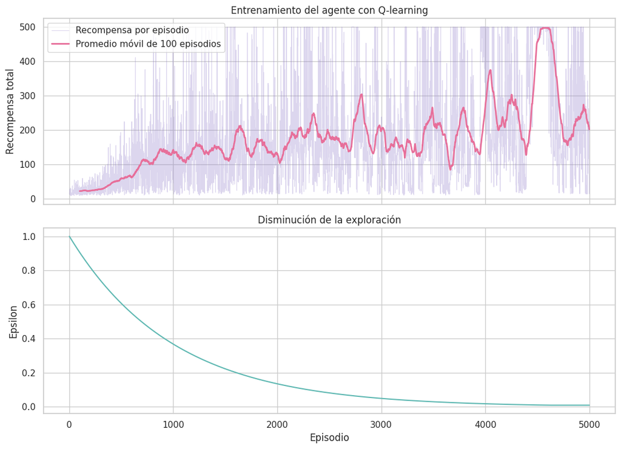

```python
promedio_movil = (
    pd.Series(recompensas_entrenamiento)
    .rolling(window=100, min_periods=100)
    .mean()
)

episodios = np.arange(1, n_episodios + 1)

fig, axes = plt.subplots(
    2, 1,
    figsize=(11, 8),
    sharex=True
)

axes[0].plot(
    episodios,
    recompensas_entrenamiento,
    color="#8C78C8",
    alpha=0.3,
    linewidth=0.8,
    label="Recompensa por episodio"
)

axes[0].plot(
    episodios,
    promedio_movil,
    color="#E76F9A",
    linewidth=2,
    label="Promedio móvil de 100 episodios"
)

axes[0].set_title("Entrenamiento del agente con Q-learning")
axes[0].set_ylabel("Recompensa total")
axes[0].legend()

axes[1].plot(
    episodios,
    historial_epsilon,
    color="#5EB8B2"
)

axes[1].set_xlabel("Episodio")
axes[1].set_ylabel("Epsilon")
axes[1].set_title("Disminución de la exploración")

plt.tight_layout()
plt.show()
```

La gráfica muestra una mejora respecto al inicio: el promedio móvil aumenta desde aproximadamente 20 puntos y alcanza valores cercanos a 500 alrededor de los episodios 4,500 a 4,600. Sin embargo, después vuelve a disminuir y termina cerca de 200 puntos. Esto indica que el aprendizaje presentó avances, pero no se estabilizó en el máximo desempeño.

En la gráfica inferior, ε disminuye de 1 a 0.01, por lo que el agente pasa de explorar constantemente a utilizar principalmente la tabla Q. Aun con poca exploración, persisten fluctuaciones mientras la tabla sigue actualizándose.

Por ello, alcanzar 500 puntos durante una parte del entrenamiento no garantiza que el modelo final mantenga ese resultado. Su desempeño se comprobará en una evaluación independiente, sin exploración ni actualizaciones de la tabla Q.

### Paso 41. Evaluación del agente entrenado

Se realizarán 1,000 episodios utilizando únicamente las acciones con mayor valor Q. Se usarán las mismas semillas iniciales de la evaluación del agente aleatorio para facilitar la comparación.

```python
env_prueba_q = gym.make("CartPole-v1")
rng_prueba_q = np.random.default_rng(SEMILLA + 10000)

recompensas_q = []

for episodio in range(1000):

    observacion, informacion = env_prueba_q.reset(
        seed=SEMILLA + episodio
    )

    done = False
    recompensa_total = 0

    while not done:

        estado = discretizar_estado(observacion)

        # Epsilon cero: utilizar la tabla sin explorar
        accion = elegir_accion(
            estado,
            0.0,
            q_table,
            rng_prueba_q
        )

        observacion, recompensa, terminated, truncated, _ = (
            env_prueba_q.step(accion)
        )

        recompensa_total += recompensa
        done = terminated or truncated

    recompensas_q.append(recompensa_total)

env_prueba_q.close()

recompensas_q = np.asarray(recompensas_q)

comparacion_agentes = pd.DataFrame({
    "Agente": ["Aleatorio", "Q-learning"],
    "Promedio": [
        recompensas_aleatorias.mean(),
        recompensas_q.mean()
    ],
    "Mediana": [
        np.median(recompensas_aleatorias),
        np.median(recompensas_q)
    ],
    "Desviación estándar": [
        recompensas_aleatorias.std(ddof=1),
        recompensas_q.std(ddof=1)
    ],
    "Máximo": [
        recompensas_aleatorias.max(),
        recompensas_q.max()
    ],
    "Llegaron a 500 pasos (%)": [
        (recompensas_aleatorias == 500).mean() * 100,
        (recompensas_q == 500).mean() * 100
    ]
})

display(
    comparacion_agentes.style
    .format({
        "Promedio": "{:.2f}",
        "Mediana": "{:.2f}",
        "Desviación estándar": "{:.2f}",
        "Máximo": "{:.0f}",
        "Llegaron a 500 pasos (%)": "{:.2f}"
    })
    .hide(axis="index")
    .set_caption("Comparación de los agentes en 1,000 episodios")
)
```

Comparación de los agentes en 1,000 episodios

| Agente | Promedio | Mediana | Desviación estándar | Máximo | Llegaron a 500 pasos (%) |
| --- | --- | --- | --- | --- | --- |
| Aleatorio | 21.32 | 18.00 | 11.69 | 141 | 0.00 |
| Q-learning | 68.64 | 56.00 | 49.29 | 272 | 0.00 |

El agente con Q-learning obtuvo una recompensa promedio de 68.64 puntos, aproximadamente 3.22 veces el promedio del agente aleatorio, de 21.32. La mediana también aumentó de 18 a 56 puntos, lo que indica que la mejora no depende únicamente de unos pocos intentos largos.

Sin embargo, el desempeño siguió siendo variable: la desviación estándar fue de 49.29 puntos y la recompensa máxima de 272. Ninguno de los 1,000 episodios alcanzó los 500 pasos.

Por lo tanto, el agente aprendió una estrategia que supera las acciones aleatorias, pero el modelo final no logró mantener el equilibrio hasta el límite del ambiente. Los periodos cercanos a 500 puntos observados durante el entrenamiento no se conservaron en la tabla Q final.

### Paso 42. Video del agente entrenado

```python
import numpy as np
import gymnasium as gym
import imageio.v2 as imageio
import base64

from pathlib import Path
from IPython.display import HTML, display


# =========================================================
# 1. CONFIGURACIÓN
# =========================================================

SEMILLA_VIDEO = 27
N_INTENTOS = 1000
MAX_PASOS_VIDEO = 1000

carpeta_videos = Path("videos_cartpole")
carpeta_videos.mkdir(exist_ok=True)

ruta_video = carpeta_videos / "mejor_intento_con_limites.mp4"


# =========================================================
# 2. ACCIÓN DEL AGENTE CON CONTROL AUXILIAR DE POSICIÓN
# =========================================================

def accion_dentro_del_cuadro(observacion, tabla, generador):

    x, velocidad, angulo, velocidad_angular = observacion

    # Acción de Q-learning, sin exploración
    estado = discretizar_estado(observacion)
    valores_q = tabla[estado]

    mejores_acciones = np.flatnonzero(
        valores_q == valores_q.max()
    )

    accion_q = int(generador.choice(mejores_acciones))

    # Anticipar el desplazamiento del carro
    posicion_prevista = x + 0.6 * velocidad

    # Intervenir antes de acercarse a los bordes
    if abs(x) > 1.5 or abs(posicion_prevista) > 1.7:

        control = (
            0.8 * x
            + 1.2 * velocidad
            + 15.0 * angulo
            + 2.5 * velocidad_angular
        )

        return int(control > 0)

    # Cerca del centro, utilizar Q-learning
    zona_central = 0.35

    if (
        abs(x) <= zona_central
        and abs(posicion_prevista) <= zona_central
    ):
        return accion_q

    # Favorecer el regreso al centro
    angulo_objetivo = np.clip(
        0.035 * x + 0.06 * velocidad,
        -0.08,
        0.08
    )

    control = (
        12.0 * (angulo - angulo_objetivo)
        + 2.0 * velocidad_angular
    )

    return int(control > 0)


# =========================================================
# 3. BUSCAR EL MEJOR INTENTO
# =========================================================

env_busqueda = gym.make(
    "CartPole-v1",
    max_episode_steps=MAX_PASOS_VIDEO
)

mejor_recompensa = -np.inf
mejores_acciones = []
mejor_semilla = None
mejor_intento = None
intentos_evaluados = 0

try:
    for intento in range(N_INTENTOS):

        semilla_intento = SEMILLA_VIDEO + intento

        observacion, _ = env_busqueda.reset(
            seed=semilla_intento
        )

        generador = np.random.default_rng(
            SEMILLA_VIDEO + 10000 + intento
        )

        acciones = []
        recompensa_total = 0

        for paso in range(MAX_PASOS_VIDEO):

            accion = accion_dentro_del_cuadro(
                observacion,
                q_table,
                generador
            )

            acciones.append(accion)

            observacion, recompensa, terminated, truncated, _ = (
                env_busqueda.step(accion)
            )

            recompensa_total += recompensa

            if terminated or truncated:
                break

        intentos_evaluados += 1

        if recompensa_total > mejor_recompensa:

            mejor_recompensa = recompensa_total
            mejores_acciones = acciones.copy()
            mejor_semilla = semilla_intento
            mejor_intento = intento + 1

        if (intento + 1) % 100 == 0:
            print(
                f"Intentos evaluados: {intento + 1} | "
                f"Mejor recompensa: {mejor_recompensa:.0f}"
            )

        # Ya se alcanzó la máxima recompensa posible
        if mejor_recompensa == MAX_PASOS_VIDEO:
            print(
                f"Se alcanzaron {MAX_PASOS_VIDEO} puntos "
                f"en el intento {intento + 1}."
            )
            break

finally:
    env_busqueda.close()


# =========================================================
# 4. GRABAR EL MEJOR INTENTO COMPLETO
# =========================================================

env_video = gym.make(
    "CartPole-v1",
    render_mode="rgb_array",
    max_episode_steps=MAX_PASOS_VIDEO
)

recompensa_grabada = 0
pasos_grabados = 0
max_desplazamiento = 0

try:
    observacion, _ = env_video.reset(seed=mejor_semilla)

    max_desplazamiento = abs(float(observacion[0]))
    fps = env_video.metadata.get("render_fps", 50)

    with imageio.get_writer(
        str(ruta_video),
        fps=fps,
        codec="libx264",
        macro_block_size=1
    ) as escritor:

        # Incluir el estado inicial
        escritor.append_data(env_video.render())

        # Reproducir exactamente las acciones seleccionadas
        for accion in mejores_acciones:

            observacion, recompensa, terminated, truncated, _ = (
                env_video.step(accion)
            )

            recompensa_grabada += recompensa
            pasos_grabados += 1

            max_desplazamiento = max(
                max_desplazamiento,
                abs(float(observacion[0]))
            )

            # Guardar todos los pasos, incluido el último
            escritor.append_data(env_video.render())

            if terminated or truncated:
                break

finally:
    env_video.close()

# Verificar que el video reprodujo el resultado seleccionado
assert np.isclose(recompensa_grabada, mejor_recompensa), (
    "La recompensa grabada no coincide con el mejor intento."
)

assert pasos_grabados == len(mejores_acciones), (
    "No se reprodujeron todas las acciones del mejor intento."
)


# =========================================================
# 5. MOSTRAR RESULTADOS Y VIDEO
# =========================================================

print(f"\nIntentos evaluados: {intentos_evaluados}")
print(f"Mejor intento: {mejor_intento}")
print(f"Recompensa: {recompensa_grabada:.0f}")
print(f"Pasos grabados: {pasos_grabados}")
print(f"Máximo desplazamiento desde el centro: {max_desplazamiento:.3f} m")
print(f"Video guardado en: {ruta_video}")

video_base64 = base64.b64encode(
    ruta_video.read_bytes()
).decode("ascii")

display(HTML(
    f"""
    <video width="800" controls>
        <source
            src="data:video/mp4;base64,{video_base64}"
            type="video/mp4">
    </video>
    """
))
```

```
Se alcanzaron 1000 puntos en el intento 1.

Intentos evaluados: 1
Mejor intento: 1
Recompensa: 1000
Pasos grabados: 1000
Máximo desplazamiento desde el centro: 1.964 m
Video guardado en: videos_cartpole/mejor_intento_con_limites.mp4
```

[video not shown]

El video muestra el mejor intento encontrado al utilizar la tabla Q junto con un control auxiliar de posición. Este control interviene cuando el carro se aleja del centro o se aproxima a los bordes, buscando corregir su movimiento mientras mantiene el equilibrio del poste.

La grabación incluye el intento completo hasta el fallo o el límite de 1,000 pasos. Como se seleccionó el mejor resultado, el video no representa el desempeño promedio. Además, el comportamiento observado corresponde a la combinación de Q-learning y control auxiliar, por lo que no debe atribuirse únicamente al aprendizaje del agente.

## Conclusión

En este tutorial se exploraron las pruebas múltiples y el aprendizaje por refuerzo. En NCI60, PCA permitió representar las 6,830 variables genéticas mediante 32 componentes que conservaron el 80.07 % de la variación. Después de formar los clusters y comparar dos de ellos, se identificaron 2,577 variables significativas sin corrección. Esta cantidad disminuyó a 188 con Bonferroni, 191 con Holm y 868 con Benjamini–Hochberg. Los resultados muestran que considerar la cantidad de pruebas cambia considerablemente la selección y que cada método responde a un criterio distinto de control del error.

La simulación de monedas permitió comprender que un resultado poco probable de manera individual puede aparecer con mayor frecuencia cuando existen muchas oportunidades. Sin embargo, las diferencias genéticas deben interpretarse como exploratorias, porque los grupos se construyeron con los mismos datos utilizados en las pruebas. Las correcciones no eliminan esta limitación ni demuestran importancia biológica.

En CartPole, Q-learning obtuvo una recompensa promedio de 68.64 puntos, frente a 21.32 del agente aleatorio. Esto muestra una mejora, aunque ningún episodio de la evaluación final alcanzó los 500 pasos. Las fluctuaciones del entrenamiento también evidenciaron que alcanzar buenos resultados temporalmente no garantiza conservarlos en el modelo final. Posteriormente se añadió un control auxiliar de posición para la demostración en video, cuyo comportamiento debe distinguirse del desempeño de Q-learning por sí solo.

La actividad permitió reconocer la importancia de evaluar los resultados junto con sus supuestos y limitaciones. Tanto en las pruebas estadísticas como en el entrenamiento del agente, un resultado favorable aislado requiere una evaluación más amplia antes de obtener conclusiones.